# Risk Factor Analysis

## Outcome Variable

**Outcome Variable:** pers_wasted624

## Predictor Variables

**Intervention Variable:** ever_co06

**Adjustment Set:**

- sex
- arm
- brthmon
- vagbrth
- single
- W_mage
- W_mhtcm
- W_mwtkg
- W_mbmi
- W_meducyrs
- W_feducyrs
- W_parity
- delta_brthmon
- delta_vagbrth
- delta_single
- delta_W_mage
- delta_W_mhtcm
- delta_W_mwtkg
- delta_W_mbmi
- delta_W_meducyrs
- delta_W_feducyrs
- delta_W_parity

## Stratifying Variables

The analysis was stratified on these variable(s):

- studyid
- country

## Data Summary

| studyid | country | ever_co06 | pers_wasted624 | n_cell | n |
| --- | --- | --- | --- | --- | --- |
| CMC-V-BCS-2002 | INDIA | 0 | 0 | 317 | 370 |
| CMC-V-BCS-2002 | INDIA | 0 | 1 | 22 | 370 |
| CMC-V-BCS-2002 | INDIA | 1 | 0 | 25 | 370 |
| CMC-V-BCS-2002 | INDIA | 1 | 1 | 6 | 370 |
| CMIN | BANGLADESH | 0 | 0 | 222 | 252 |
| CMIN | BANGLADESH | 0 | 1 | 17 | 252 |
| CMIN | BANGLADESH | 1 | 0 | 5 | 252 |
| CMIN | BANGLADESH | 1 | 1 | 8 | 252 |
| COHORTS | GUATEMALA | 0 | 0 | 956 | 1016 |
| COHORTS | GUATEMALA | 0 | 1 | 33 | 1016 |
| COHORTS | GUATEMALA | 1 | 0 | 19 | 1016 |
| COHORTS | GUATEMALA | 1 | 1 | 8 | 1016 |
| COHORTS | INDIA | 0 | 0 | 6006 | 6888 |
| COHORTS | INDIA | 0 | 1 | 550 | 6888 |
| COHORTS | INDIA | 1 | 0 | 112 | 6888 |
| COHORTS | INDIA | 1 | 1 | 220 | 6888 |
| COHORTS | PHILIPPINES | 0 | 0 | 2537 | 2808 |
| COHORTS | PHILIPPINES | 0 | 1 | 184 | 2808 |
| COHORTS | PHILIPPINES | 1 | 0 | 45 | 2808 |
| COHORTS | PHILIPPINES | 1 | 1 | 42 | 2808 |
| CONTENT | PERU | 0 | 0 | 215 | 215 |
| CONTENT | PERU | 0 | 1 | 0 | 215 |
| CONTENT | PERU | 1 | 0 | 0 | 215 |
| CONTENT | PERU | 1 | 1 | 0 | 215 |
| EE | PAKISTAN | 0 | 0 | 288 | 373 |
| EE | PAKISTAN | 0 | 1 | 24 | 373 |
| EE | PAKISTAN | 1 | 0 | 36 | 373 |
| EE | PAKISTAN | 1 | 1 | 25 | 373 |
| GMS-Nepal | NEPAL | 0 | 0 | 463 | 590 |
| GMS-Nepal | NEPAL | 0 | 1 | 93 | 590 |

[output cut: 90 more lines]

The following strata were considered:

- studyid: CMC-V-BCS-2002, country: INDIA
- studyid: CMIN, country: BANGLADESH
- studyid: COHORTS, country: GUATEMALA
- studyid: COHORTS, country: INDIA
- studyid: COHORTS, country: PHILIPPINES
- studyid: CONTENT, country: PERU
- studyid: EE, country: PAKISTAN
- studyid: GMS-Nepal, country: NEPAL
- studyid: Guatemala BSC, country: GUATEMALA
- studyid: IRC, country: INDIA
- studyid: JiVitA-3, country: BANGLADESH
- studyid: JiVitA-4, country: BANGLADESH
- studyid: Keneba, country: GAMBIA
- studyid: LCNI-5, country: MALAWI
- studyid: MAL-ED, country: BANGLADESH
- studyid: MAL-ED, country: BRAZIL
- studyid: MAL-ED, country: INDIA
- studyid: MAL-ED, country: NEPAL
- studyid: MAL-ED, country: PERU
- studyid: MAL-ED, country: SOUTH AFRICA
- studyid: MAL-ED, country: TANZANIA, UNITED REPUBLIC OF
- studyid: NIH-Birth, country: BANGLADESH
- studyid: NIH-Crypto, country: BANGLADESH
- studyid: PROBIT, country: BELARUS
- studyid: PROVIDE, country: BANGLADESH
- studyid: ResPak, country: PAKISTAN
- studyid: SAS-CompFeed, country: INDIA
- studyid: SAS-FoodSuppl, country: INDIA
- studyid: TanzaniaChild2, country: TANZANIA, UNITED REPUBLIC OF
- studyid: ZVITAMBO, country: ZIMBABWE

### Dropped Strata

Some strata were dropped due to rare outcomes:

- studyid: CONTENT, country: PERU
- studyid: Guatemala BSC, country: GUATEMALA
- studyid: LCNI-5, country: MALAWI
- studyid: MAL-ED, country: BANGLADESH
- studyid: MAL-ED, country: BRAZIL
- studyid: MAL-ED, country: NEPAL
- studyid: MAL-ED, country: PERU
- studyid: MAL-ED, country: SOUTH AFRICA
- studyid: MAL-ED, country: TANZANIA, UNITED REPUBLIC OF
- studyid: PROBIT, country: BELARUS

## Methods Detail

We’re interested in the causal parameters $E[Y_a]$ for all values of $a \in \mathcal{A}$. These parameters represent the mean outcome if, possibly contrary to fact, we intervened to set all units to have $A=a$. Under the randomization and positivity assumptions, these are identified by the statistical parameters $\psi_a=E_W[E_{Y|A,W}(Y|A=a,W)]$. In addition, we’re interested in the mean of $Y$, $E[Y]$ under no intervention (the observed mean). We will estimate these parameters by using SuperLearner to fit the relevant likelihood factors – $E_{Y|A,W}(Y|A=a,W)$ and $p(A=a|W)$, and then updating our likelihood fit using a joint TMLE.

For unadjusted analyses ($W=\{\}$), initial likelihoods were estimated using Lrnr_glm to estimate the simple $E(Y|A)$ and Lrnr_mean to estimate $p(A)$. For adjusted analyses, a small library containing Lrnr_glmnet, Lrnr_xgboost, and Lrnr_mean was used.

Having estimated these parameters, we will then use the delta method to estimate relative risks and attributable risks relative to a prespecified baseline level of $A$.

# Results Detail

## Results Plots

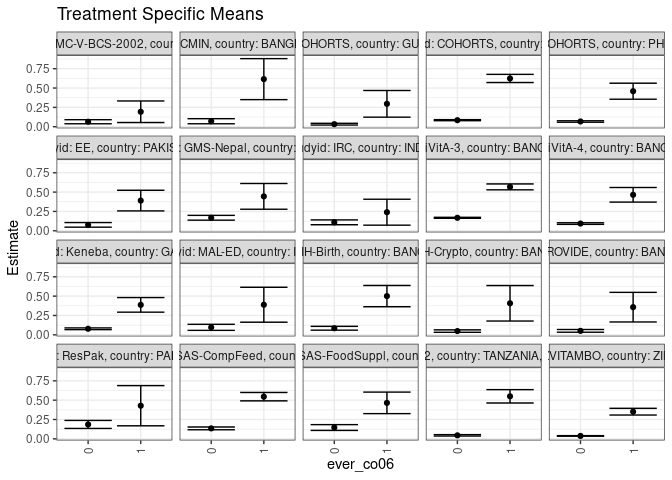

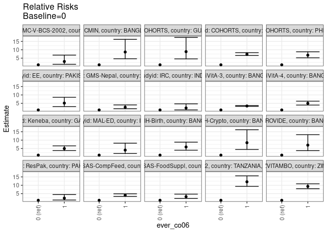

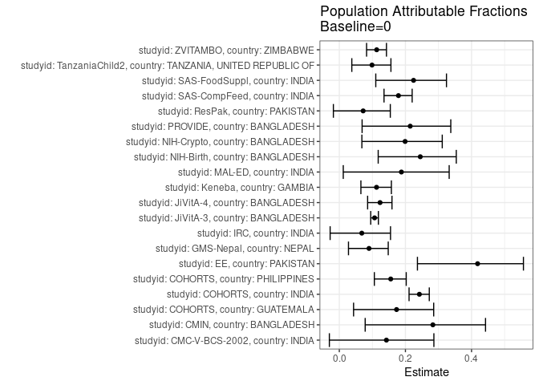

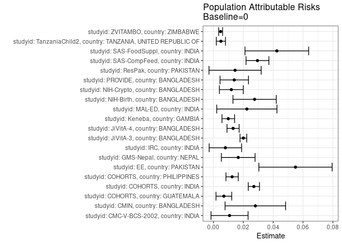

## Results Table

### Parameter: TSM

| studyid | country | intervention_level | baseline_level | estimate | ci_lower | ci_upper |
| --- | --- | --- | --- | --- | --- | --- |
| CMC-V-BCS-2002 | INDIA | 0 | NA | 0.0648968 | 0.0386378 | 0.0911557 |
| CMC-V-BCS-2002 | INDIA | 1 | NA | 0.1935484 | 0.0542844 | 0.3328124 |
| CMIN | BANGLADESH | 0 | NA | 0.0711297 | 0.0384773 | 0.1037821 |
| CMIN | BANGLADESH | 1 | NA | 0.6153846 | 0.3503965 | 0.8803728 |
| COHORTS | GUATEMALA | 0 | NA | 0.0333670 | 0.0221687 | 0.0445654 |
| COHORTS | GUATEMALA | 1 | NA | 0.2962963 | 0.1239753 | 0.4686172 |
| COHORTS | INDIA | 0 | NA | 0.0847145 | 0.0779646 | 0.0914643 |
| COHORTS | INDIA | 1 | NA | 0.6240114 | 0.5713497 | 0.6766732 |
| COHORTS | PHILIPPINES | 0 | NA | 0.0679649 | 0.0585238 | 0.0774060 |
| COHORTS | PHILIPPINES | 1 | NA | 0.4590425 | 0.3554145 | 0.5626704 |
| EE | PAKISTAN | 0 | NA | 0.0764150 | 0.0467018 | 0.1061282 |
| EE | PAKISTAN | 1 | NA | 0.3903369 | 0.2571207 | 0.5235530 |
| GMS-Nepal | NEPAL | 0 | NA | 0.1681467 | 0.1369844 | 0.1993091 |
| GMS-Nepal | NEPAL | 1 | NA | 0.4447195 | 0.2786564 | 0.6107827 |
| IRC | INDIA | 0 | NA | 0.1093750 | 0.0781199 | 0.1406301 |
| IRC | INDIA | 1 | NA | 0.2400000 | 0.0723815 | 0.4076185 |
| JiVitA-3 | BANGLADESH | 0 | NA | 0.1677643 | 0.1614178 | 0.1741108 |
| JiVitA-3 | BANGLADESH | 1 | NA | 0.5673634 | 0.5291710 | 0.6055557 |
| JiVitA-4 | BANGLADESH | 0 | NA | 0.0934711 | 0.0832557 | 0.1036864 |
| JiVitA-4 | BANGLADESH | 1 | NA | 0.4649342 | 0.3703938 | 0.5594745 |
| Keneba | GAMBIA | 0 | NA | 0.0783916 | 0.0671331 | 0.0896502 |
| Keneba | GAMBIA | 1 | NA | 0.3872321 | 0.2928777 | 0.4815864 |
| MAL-ED | INDIA | 0 | NA | 0.0967742 | 0.0573537 | 0.1361947 |
| MAL-ED | INDIA | 1 | NA | 0.3888889 | 0.1631997 | 0.6145780 |
| NIH-Birth | BANGLADESH | 0 | NA | 0.0849839 | 0.0604283 | 0.1095396 |
| NIH-Birth | BANGLADESH | 1 | NA | 0.5005021 | 0.3631018 | 0.6379024 |
| NIH-Crypto | BANGLADESH | 0 | NA | 0.0482797 | 0.0324912 | 0.0640682 |
| NIH-Crypto | BANGLADESH | 1 | NA | 0.4076593 | 0.1784509 | 0.6368678 |
| PROVIDE | BANGLADESH | 0 | NA | 0.0510933 | 0.0332575 | 0.0689292 |
| PROVIDE | BANGLADESH | 1 | NA | 0.3574736 | 0.1663847 | 0.5485624 |
| ResPak | PAKISTAN | 0 | NA | 0.1863636 | 0.1347978 | 0.2379295 |
| ResPak | PAKISTAN | 1 | NA | 0.4285714 | 0.1687909 | 0.6883520 |
| SAS-CompFeed | INDIA | 0 | NA | 0.1353672 | 0.1174481 | 0.1532863 |
| SAS-CompFeed | INDIA | 1 | NA | 0.5453168 | 0.4909595 | 0.5996740 |
| SAS-FoodSuppl | INDIA | 0 | NA | 0.1465979 | 0.1094798 | 0.1837161 |
| SAS-FoodSuppl | INDIA | 1 | NA | 0.4652507 | 0.3262179 | 0.6042835 |
| TanzaniaChild2 | TANZANIA, UNITED REPUBLIC OF | 0 | NA | 0.0455455 | 0.0362596 | 0.0548315 |
| TanzaniaChild2 | TANZANIA, UNITED REPUBLIC OF | 1 | NA | 0.5500000 | 0.4635436 | 0.6364564 |
| ZVITAMBO | ZIMBABWE | 0 | NA | 0.0377760 | 0.0341001 | 0.0414519 |
| ZVITAMBO | ZIMBABWE | 1 | NA | 0.3511388 | 0.3077157 | 0.3945619 |

### Parameter: E(Y)

| studyid | country | intervention_level | baseline_level | estimate | ci_lower | ci_upper |
| --- | --- | --- | --- | --- | --- | --- |
| CMC-V-BCS-2002 | INDIA | NA | NA | 0.0756757 | 0.0486905 | 0.1026609 |
| CMIN | BANGLADESH | NA | NA | 0.0992063 | 0.0622241 | 0.1361886 |
| COHORTS | GUATEMALA | NA | NA | 0.0403543 | 0.0282479 | 0.0524607 |
| COHORTS | INDIA | NA | NA | 0.1117886 | 0.1043466 | 0.1192306 |
| COHORTS | PHILIPPINES | NA | NA | 0.0804843 | 0.0704205 | 0.0905481 |
| EE | PAKISTAN | NA | NA | 0.1313673 | 0.0970401 | 0.1656945 |
| GMS-Nepal | NEPAL | NA | NA | 0.1847458 | 0.1534039 | 0.2160876 |
| IRC | INDIA | NA | NA | 0.1173594 | 0.0861296 | 0.1485892 |
| JiVitA-3 | BANGLADESH | NA | NA | 0.1878008 | 0.1812627 | 0.1943389 |
| JiVitA-4 | BANGLADESH | NA | NA | 0.1066106 | 0.0960765 | 0.1171447 |
| Keneba | GAMBIA | NA | NA | 0.0883377 | 0.0767324 | 0.0999430 |
| MAL-ED | INDIA | NA | NA | 0.1191489 | 0.0776405 | 0.1606574 |
| NIH-Birth | BANGLADESH | NA | NA | 0.1125461 | 0.0859151 | 0.1391771 |
| NIH-Crypto | BANGLADESH | NA | NA | 0.0602740 | 0.0429977 | 0.0775502 |
| PROVIDE | BANGLADESH | NA | NA | 0.0650407 | 0.0455353 | 0.0845460 |
| ResPak | PAKISTAN | NA | NA | 0.2008547 | 0.1494120 | 0.2522974 |
| SAS-CompFeed | INDIA | NA | NA | 0.1648590 | 0.1452632 | 0.1844548 |
| SAS-FoodSuppl | INDIA | NA | NA | 0.1890547 | 0.1507312 | 0.2273783 |
| TanzaniaChild2 | TANZANIA, UNITED REPUBLIC OF | NA | NA | 0.0505451 | 0.0409848 | 0.0601054 |
| ZVITAMBO | ZIMBABWE | NA | NA | 0.0425909 | 0.0387699 | 0.0464119 |

### Parameter: RR

| studyid | country | intervention_level | baseline_level | estimate | ci_lower | ci_upper |
| --- | --- | --- | --- | --- | --- | --- |
| CMC-V-BCS-2002 | INDIA | 0 | 0 | 1.000000 | 1.000000 | 1.000000 |
| CMC-V-BCS-2002 | INDIA | 1 | 0 | 2.982405 | 1.306343 | 6.808882 |
| CMIN | BANGLADESH | 0 | 0 | 1.000000 | 1.000000 | 1.000000 |
| CMIN | BANGLADESH | 1 | 0 | 8.651584 | 4.610498 | 16.234669 |
| COHORTS | GUATEMALA | 0 | 0 | 1.000000 | 1.000000 | 1.000000 |
| COHORTS | GUATEMALA | 1 | 0 | 8.879910 | 4.537246 | 17.379001 |
| COHORTS | INDIA | 0 | 0 | 1.000000 | 1.000000 | 1.000000 |
| COHORTS | INDIA | 1 | 0 | 7.366055 | 6.560708 | 8.270261 |
| COHORTS | PHILIPPINES | 0 | 0 | 1.000000 | 1.000000 | 1.000000 |
| COHORTS | PHILIPPINES | 1 | 0 | 6.754114 | 5.184698 | 8.798595 |
| EE | PAKISTAN | 0 | 0 | 1.000000 | 1.000000 | 1.000000 |
| EE | PAKISTAN | 1 | 0 | 5.108118 | 3.037698 | 8.589685 |
| GMS-Nepal | NEPAL | 0 | 0 | 1.000000 | 1.000000 | 1.000000 |
| GMS-Nepal | NEPAL | 1 | 0 | 2.644830 | 1.744220 | 4.010461 |
| IRC | INDIA | 0 | 0 | 1.000000 | 1.000000 | 1.000000 |
| IRC | INDIA | 1 | 0 | 2.194286 | 1.031740 | 4.666768 |
| JiVitA-3 | BANGLADESH | 0 | 0 | 1.000000 | 1.000000 | 1.000000 |
| JiVitA-3 | BANGLADESH | 1 | 0 | 3.381908 | 3.132585 | 3.651074 |
| JiVitA-4 | BANGLADESH | 0 | 0 | 1.000000 | 1.000000 | 1.000000 |
| JiVitA-4 | BANGLADESH | 1 | 0 | 4.974097 | 3.946238 | 6.269678 |
| Keneba | GAMBIA | 0 | 0 | 1.000000 | 1.000000 | 1.000000 |
| Keneba | GAMBIA | 1 | 0 | 4.939713 | 3.724477 | 6.551463 |
| MAL-ED | INDIA | 0 | 0 | 1.000000 | 1.000000 | 1.000000 |
| MAL-ED | INDIA | 1 | 0 | 4.018518 | 1.977591 | 8.165737 |
| NIH-Birth | BANGLADESH | 0 | 0 | 1.000000 | 1.000000 | 1.000000 |
| NIH-Birth | BANGLADESH | 1 | 0 | 5.889373 | 3.949183 | 8.782755 |
| NIH-Crypto | BANGLADESH | 0 | 0 | 1.000000 | 1.000000 | 1.000000 |
| NIH-Crypto | BANGLADESH | 1 | 0 | 8.443703 | 4.406146 | 16.181063 |
| PROVIDE | BANGLADESH | 0 | 0 | 1.000000 | 1.000000 | 1.000000 |
| PROVIDE | BANGLADESH | 1 | 0 | 6.996482 | 3.695571 | 13.245787 |
| ResPak | PAKISTAN | 0 | 0 | 1.000000 | 1.000000 | 1.000000 |
| ResPak | PAKISTAN | 1 | 0 | 2.299652 | 1.181089 | 4.477561 |
| SAS-CompFeed | INDIA | 0 | 0 | 1.000000 | 1.000000 | 1.000000 |
| SAS-CompFeed | INDIA | 1 | 0 | 4.028427 | 3.334564 | 4.866669 |
| SAS-FoodSuppl | INDIA | 0 | 0 | 1.000000 | 1.000000 | 1.000000 |
| SAS-FoodSuppl | INDIA | 1 | 0 | 3.173651 | 2.144760 | 4.696125 |
| TanzaniaChild2 | TANZANIA, UNITED REPUBLIC OF | 0 | 0 | 1.000000 | 1.000000 | 1.000000 |
| TanzaniaChild2 | TANZANIA, UNITED REPUBLIC OF | 1 | 0 | 12.075824 | 9.334897 | 15.621547 |
| ZVITAMBO | ZIMBABWE | 0 | 0 | 1.000000 | 1.000000 | 1.000000 |
| ZVITAMBO | ZIMBABWE | 1 | 0 | 9.295298 | 7.942353 | 10.878712 |

### Parameter: PAR

| studyid | country | intervention_level | baseline_level | estimate | ci_lower | ci_upper |
| --- | --- | --- | --- | --- | --- | --- |
| CMC-V-BCS-2002 | INDIA | 0 | NA | 0.0107789 | -0.0016393 | 0.0231971 |
| CMIN | BANGLADESH | 0 | NA | 0.0280766 | 0.0077909 | 0.0483623 |
| COHORTS | GUATEMALA | 0 | NA | 0.0069873 | 0.0017121 | 0.0122625 |
| COHORTS | INDIA | 0 | NA | 0.0270741 | 0.0232969 | 0.0308514 |
| COHORTS | PHILIPPINES | 0 | NA | 0.0125195 | 0.0083787 | 0.0166602 |
| EE | PAKISTAN | 0 | NA | 0.0549523 | 0.0304184 | 0.0794861 |
| GMS-Nepal | NEPAL | 0 | NA | 0.0165990 | 0.0052976 | 0.0279004 |
| IRC | INDIA | 0 | NA | 0.0079844 | -0.0028711 | 0.0188399 |
| JiVitA-3 | BANGLADESH | 0 | NA | 0.0200365 | 0.0177876 | 0.0222853 |
| JiVitA-4 | BANGLADESH | 0 | NA | 0.0131396 | 0.0090672 | 0.0172119 |
| Keneba | GAMBIA | 0 | NA | 0.0099461 | 0.0057326 | 0.0141595 |
| MAL-ED | INDIA | 0 | NA | 0.0223747 | 0.0021997 | 0.0425498 |
| NIH-Birth | BANGLADESH | 0 | NA | 0.0275622 | 0.0130657 | 0.0420587 |
| NIH-Crypto | BANGLADESH | 0 | NA | 0.0119943 | 0.0039959 | 0.0199927 |
| PROVIDE | BANGLADESH | 0 | NA | 0.0139473 | 0.0044245 | 0.0234702 |
| ResPak | PAKISTAN | 0 | NA | 0.0144911 | -0.0029872 | 0.0319693 |
| SAS-CompFeed | INDIA | 0 | NA | 0.0294918 | 0.0218349 | 0.0371487 |
| SAS-FoodSuppl | INDIA | 0 | NA | 0.0424568 | 0.0211381 | 0.0637755 |
| TanzaniaChild2 | TANZANIA, UNITED REPUBLIC OF | 0 | NA | 0.0049995 | 0.0019204 | 0.0080787 |
| ZVITAMBO | ZIMBABWE | 0 | NA | 0.0048149 | 0.0034821 | 0.0061477 |

### Parameter: PAF

| studyid | country | intervention_level | baseline_level | estimate | ci_lower | ci_upper |
| --- | --- | --- | --- | --- | --- | --- |
| CMC-V-BCS-2002 | INDIA | 0 | NA | 0.1424357 | -0.0300892 | 0.2860653 |
| CMIN | BANGLADESH | 0 | NA | 0.2830126 | 0.0782623 | 0.4422806 |
| COHORTS | GUATEMALA | 0 | NA | 0.1731485 | 0.0431505 | 0.2854850 |
| COHORTS | INDIA | 0 | NA | 0.2421906 | 0.2109914 | 0.2721561 |
| COHORTS | PHILIPPINES | 0 | NA | 0.1555515 | 0.1059652 | 0.2023876 |
| EE | PAKISTAN | 0 | NA | 0.4183103 | 0.2363128 | 0.5569352 |
| GMS-Nepal | NEPAL | 0 | NA | 0.0898479 | 0.0277489 | 0.1479806 |
| IRC | INDIA | 0 | NA | 0.0680339 | -0.0277289 | 0.1548735 |
| JiVitA-3 | BANGLADESH | 0 | NA | 0.1066900 | 0.0950204 | 0.1182092 |
| JiVitA-4 | BANGLADESH | 0 | NA | 0.1232482 | 0.0856420 | 0.1593076 |
| Keneba | GAMBIA | 0 | NA | 0.1125916 | 0.0652952 | 0.1574947 |
| MAL-ED | INDIA | 0 | NA | 0.1877880 | 0.0119633 | 0.3323241 |
| NIH-Birth | BANGLADESH | 0 | NA | 0.2448967 | 0.1176344 | 0.3538043 |
| NIH-Crypto | BANGLADESH | 0 | NA | 0.1989961 | 0.0682680 | 0.3113822 |
| PROVIDE | BANGLADESH | 0 | NA | 0.2144400 | 0.0689551 | 0.3371914 |
| ResPak | PAKISTAN | 0 | NA | 0.0721470 | -0.0179275 | 0.1542510 |
| SAS-CompFeed | INDIA | 0 | NA | 0.1788912 | 0.1352336 | 0.2203447 |
| SAS-FoodSuppl | INDIA | 0 | NA | 0.2245740 | 0.1103113 | 0.3241619 |
| TanzaniaChild2 | TANZANIA, UNITED REPUBLIC OF | 0 | NA | 0.0989126 | 0.0378212 | 0.1561252 |
| ZVITAMBO | ZIMBABWE | 0 | NA | 0.1130503 | 0.0824749 | 0.1426068 |